# Outlier Treatment (for Continuous Variables):

1. One main way detect outliers is Visualization
2. Box-plot or Quantile method
3. Histogram
4. Stem and lef plot
5. Scatter Plot (bivariate)
6. Basic sense of how each column should be

```python
import matplotlib.pyplot as plt    #pyplot is the sub-package of the master package matplotlib imported and referred as "plt"
# matplotlib is the master-package for visualisations in python
# Plot functions of "PANDAS" are built over(on top of) the methods in "MATPLOTLIB"
import pandas as pd
import numpy as np
import re
```

```python
#Importing your data - which is already missing value treated
ip=pd.read_csv(r"wages_unformatted_for_outliers.csv",index_col=False)
```

```python
%matplotlib inline
```

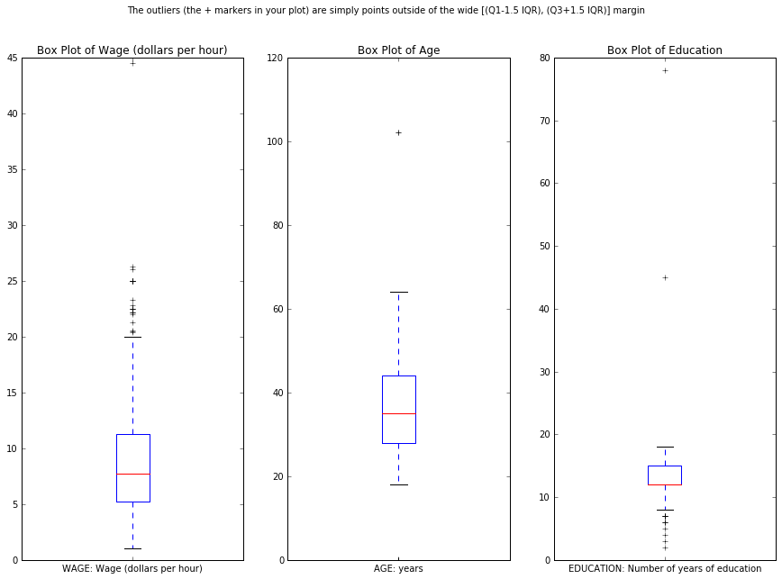

```python
#Box Plot for all continous variables: 'WAGE: Wage (dollars per hour)', 'AGE: years', 'EDUCATION: Number of years of education'
fig, axes = plt.subplots(nrows=1, ncols=3,figsize=(15,10))
ip['WAGE: Wage (dollars per hour)'].plot(kind='box',ax=axes[0],showfliers=True)
axes[0].set_title("Box Plot of Wage (dollars per hour)")

ip['AGE: years'].plot(kind='box',ax=axes[1],showfliers=True)
axes[1].set_title("Box Plot of Age")

ip['EDUCATION: Number of years of education'].plot(kind='box',ax=axes[2],showfliers=True)
axes[2].set_title("Box Plot of Education")
plt.suptitle('The outliers (the + markers in your plot) are simply points outside of the wide [(Q1-1.5 IQR), (Q3+1.5 IQR)] margin')
```

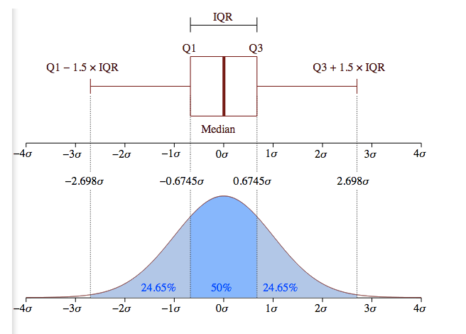

```python
from IPython.display import Image
Image(filename=r"Outlier_IQR.PNG")
```

- IQR or Inter Quartile Region [(Q1-1.5 IQR), (Q3+1.5 IQR)] margin covers 99.3% of the data (the line is known as the whiskers, hence also called the Box and Whiskers Plot).
- All the area outside of that represent only 0.7% of your data.

```python
ip_continuous=ip[['WAGE: Wage (dollars per hour)', 'AGE: years', 'EDUCATION: Number of years of education']]
```

```python
ip_continuous.quantile([0,0.25,0.5,0.75,1])
```

|  | WAGE: Wage (dollars per hour) | AGE: years | EDUCATION: Number of years of education |
| --- | --- | --- | --- |
| 0.00 | 1.000 | 0.0 | 2.0 |
| 0.25 | 5.250 | 28.0 | 12.0 |
| 0.50 | 7.765 | 35.0 | 12.0 |
| 0.75 | 11.250 | 44.0 | 15.0 |
| 1.00 | 44.500 | 102.0 | 78.0 |

```python
#what are those + marker numbers specifically
ip_outside_OnehalfIQR=ip_continuous.quantile([0.07,0.93])
ip_outside_OnehalfIQR
```

|  | WAGE: Wage (dollars per hour) | AGE: years | EDUCATION: Number of years of education |
| --- | --- | --- | --- |
| 0.07 | 3.6500 | 21.0 | 9.0 |
| 0.93 | 17.9566 | 57.0 | 17.0 |

```python
#what are those + marker numbers in the box plot specifically
for each in ip_continuous.columns:
    print "The lower end probable outliers for %s look like the following:" %(each)
    print ip_continuous[each][ip_continuous[each]<ip_outside_OnehalfIQR.ix[0.07,each]]
    print "\n"
    print "--------------"
```

```
The lower end probable outliers for WAGE: Wage (dollars per hour) look like the following:
28     3.35
40     3.35
70     3.35
73     3.50
75     3.00
92     2.85
137    3.35
165    3.35
178    3.64
199    1.00
219    3.35
227    3.50
228    3.35
231    3.50
```

[output cut: 97 more lines]

```python
#From the above deep dive into lower end outliers, we see age to be zero years. That seems unlikely. Let us investigate further
ip[ip['AGE: years']==0]
```

|  | EDUCATION: Number of years of education | SOUTH: 1=Person lives in South, 0=Person lives elsewhere | SEX: 1=Female, 0=Male | EXPERIENCE: Number of years of work experience | UNION: 1=Union member, 0=Not union member | WAGE: Wage (dollars per hour) | AGE: years | RACE: 1=Other, 2=Hispanic, 3=White | OCCUPATION: 1=Management, 2=Sales, 3=Clerical, 4=Service, 5=Professional, 6=Other | SECTOR: 0=Other, 1=Manufacturing, 2=Construction | MARR: 0=Unmarried, 1=Married |
| --- | --- | --- | --- | --- | --- | --- | --- | --- | --- | --- | --- |
| 3 | 12 | 0 | 0 | 4 | 0 | 4.00 | 0 | 3 | 6 | 0 | 0 |
| 7 | 12 | 0 | 0 | 9 | 0 | 19.47 | 0 | 3 | 6 | 0 | 0 |
| 9 | 12 | 0 | 0 | 9 | 0 | 8.75 | 0 | 3 | 6 | 0 | 0 |
| 241 | 12 | 0 | 1 | 4 | 0 | 3.80 | 0 | 3 | 2 | 0 | 0 |
| 281 | 12 | 0 | 1 | 4 | 0 | 4.13 | 0 | 3 | 3 | 0 | 1 |

# From the above table it is clear that Age: years == 0 is an outlier since Education in years and Experience in years are greater than Age

```python
for each in ip_continuous.columns:
    print "The higher end probable outliers for %s look like the following:" %(each)
    print ip_continuous[each][ip_continuous[each]>ip_outside_OnehalfIQR.ix[0.93,each]]
    print "\n"
    print "--------------"
```

```
The higher end probable outliers for WAGE: Wage (dollars per hour) look like the following:
7      19.47
14     19.98
17     22.20
19     20.55
94     19.98
104    18.50
106    26.00
156    24.98
161    21.25
168    26.29
170    44.50
176    20.00
177    22.50
180    24.98
```

[output cut: 104 more lines]

```python
#from the above higher end outliers, we can easily suspect Age to be 102 or Education to be too far beyond 18 years (like 45 years or 78 years)
ip[ip['AGE: years']>100]
```

|  | EDUCATION: Number of years of education | SOUTH: 1=Person lives in South, 0=Person lives elsewhere | SEX: 1=Female, 0=Male | EXPERIENCE: Number of years of work experience | UNION: 1=Union member, 0=Not union member | WAGE: Wage (dollars per hour) | AGE: years | RACE: 1=Other, 2=Hispanic, 3=White | OCCUPATION: 1=Management, 2=Sales, 3=Clerical, 4=Service, 5=Professional, 6=Other | SECTOR: 0=Other, 1=Manufacturing, 2=Construction | MARR: 0=Unmarried, 1=Married |
| --- | --- | --- | --- | --- | --- | --- | --- | --- | --- | --- | --- |
| 116 | 11 | 0 | 0 | 11 | 0 | 3.75 | 102 | 3 | 6 | 2 | 0 |
| 367 | 13 | 1 | 0 | 9 | 0 | 5.95 | 102 | 3 | 4 | 0 | 1 |

```python
#creation of a list of outlier elements
Age_outliers_list.append(ip['AGE: years'][ip['AGE: years']==102].unique())
Age_outliers_list
```

```
[array([0], dtype=int64), array([102], dtype=int64), array([102], dtype=int64)]
```

```python
ip[ip['EDUCATION: Number of years of education']>18]
```

|  | EDUCATION: Number of years of education | SOUTH: 1=Person lives in South, 0=Person lives elsewhere | SEX: 1=Female, 0=Male | EXPERIENCE: Number of years of work experience | UNION: 1=Union member, 0=Not union member | WAGE: Wage (dollars per hour) | AGE: years | RACE: 1=Other, 2=Hispanic, 3=White | OCCUPATION: 1=Management, 2=Sales, 3=Clerical, 4=Service, 5=Professional, 6=Other | SECTOR: 0=Other, 1=Manufacturing, 2=Construction | MARR: 0=Unmarried, 1=Married |
| --- | --- | --- | --- | --- | --- | --- | --- | --- | --- | --- | --- |
| 271 | 45 | 1 | 0 | 10 | 0 | 5.21 | 34 | 3 | 3 | 0 | 1 |
| 454 | 78 | 1 | 0 | 12 | 0 | 5.85 | 36 | 3 | 5 | 0 | 1 |

```python
ip[ip['WAGE: Wage (dollars per hour)']>40]
#the below value for Wage for an 21-year old could still be probable even though they are quite away from the normal
```

|  | EDUCATION: Number of years of education | SOUTH: 1=Person lives in South, 0=Person lives elsewhere | SEX: 1=Female, 0=Male | EXPERIENCE: Number of years of work experience | UNION: 1=Union member, 0=Not union member | WAGE: Wage (dollars per hour) | AGE: years | RACE: 1=Other, 2=Hispanic, 3=White | OCCUPATION: 1=Management, 2=Sales, 3=Clerical, 4=Service, 5=Professional, 6=Other | SECTOR: 0=Other, 1=Manufacturing, 2=Construction | MARR: 0=Unmarried, 1=Married |
| --- | --- | --- | --- | --- | --- | --- | --- | --- | --- | --- | --- |
| 170 | 14 | 0 | 1 | 1 | 0 | 44.5 | 21 | 3 | 1 | 0 | 0 |

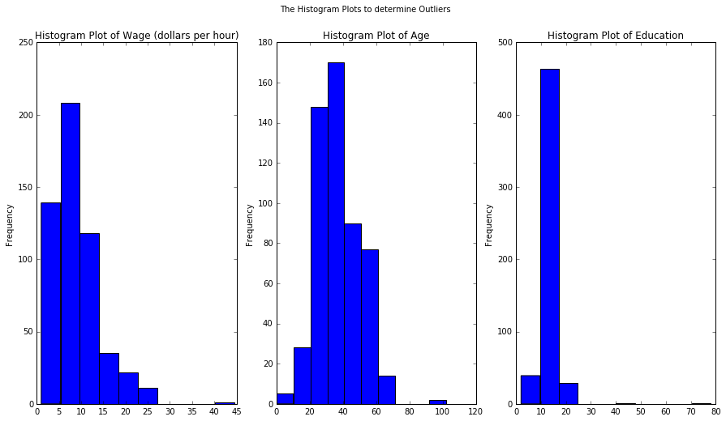

```python
#You can also view a histogram, instead of a box plot
#histogram for all continous variables: 'WAGE: Wage (dollars per hour)', 'AGE: years', 'EDUCATION: Number of years of education'
fig, axes = plt.subplots(nrows=1, ncols=3,figsize=(15,8))
ip['WAGE: Wage (dollars per hour)'].plot(kind='hist',ax=axes[0])
axes[0].set_title("Histogram Plot of Wage (dollars per hour)")

ip['AGE: years'].plot(kind='hist',ax=axes[1])
axes[1].set_title("Histogram Plot of Age")

ip['EDUCATION: Number of years of education'].plot(kind='hist',ax=axes[2])
axes[2].set_title("Histogram Plot of Education")
plt.suptitle('The Histogram Plots to determine Outliers')
```

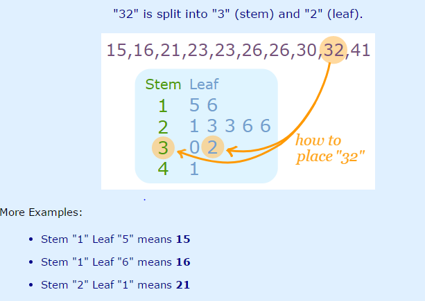

```python
#Stem and Leaf Plot: Slightly different from box plot and vilon plot, but does something similar
from IPython.display import Image
Image(filename=r"E:\2017\May\Data Handling Workshop - second installment\Session 4 - Statistical Analysis Learning Material\Learning Material\Stem and Leaf Plot.PNG")
```

```python
from collections import namedtuple
from pprint import pprint as pp
from math import floor

Stem = namedtuple('Stem', 'data, leafdigits')

data0 = Stem((ip_continuous['WAGE: Wage (dollars per hour)']),1.0)
data1 = Stem((ip_continuous['AGE: years']),1.0)
data2 = Stem((ip_continuous['EDUCATION: Number of years of education']),1.0)

def stemplot(stem):
    d = []
    interval = int(10**int(stem.leafdigits))
    for data in sorted(stem.data):
        data = int(floor(data))
        stm, lf = divmod(data,interval)
        d.append( (int(stm), int(lf)) )
    stems, leafs = list(zip(*d))
    stemwidth = max(len(str(x)) for x in stems)
    leafwidth = max(len(str(x)) for x in leafs)
    laststem, out = min(stems) - 1, []
    for s,l in d:
        while laststem < s:
            laststem += 1
            out.append('\n%*i |' % ( stemwidth, laststem))
        out.append(' %0*i' % (leafwidth, l))
    out.append('\n\nKey:\n Stem multiplier: %i\n X | Y  =>  %i*X+Y\n'
               % (interval, interval))
    return ''.join(out)

if __name__ == '__main__':
    print
    print( stemplot(data0) )
    print( stemplot(data1) )
    print( stemplot(data2) )
```

```
0 | 1 1 2 2 3 3 3 3 3 3 3 3 3 3 3 3 3 3 3 3 3 3 3 3 3 3 3 3 3 3 3 3 3 3 3 3 3 3 3 3 3 3 3 3 3 3 3 3 3 3 3 4 4 4 4 4 4 4 4 4 4 4 4 4 4 4 4 4 4 4 4 4 4 4 4 4 4 4 4 4 4 4 4 4 4 4 4 4 4 4 4 4 4 4 4 4 4 4 4 4 4 4 4 4 4 4 4 4 5 5 5 5 5 5 5 5 5 5 5 5 5 5 5 5 5 5 5 5 5 5 5 5 5 5 5 5 5 5 5 5 5 5 5 5 5 5 5 5 …
1 | 0 0 0 0 0 0 0 0 0 0 0 0 0 0 0 0 0 0 0 0 0 0 0 0 0 0 0 0 0 0 0 0 0 0 0 0 0 1 1 1 1 1 1 1 1 1 1 1 1 1 1 1 1 1 1 1 1 1 1 1 1 1 2 2 2 2 2 2 2 2 2 2 2 2 2 2 2 2 2 2 2 2 2 2 2 2 2 2 2 3 3 3 3 3 3 3 3 3 3 3 3 3 3 3 3 3 3 3 3 3 3 4 4 4 4 4 4 4 4 5 5 5 5 5 5 5 5 5 5 5 5 5 5 5 5 6 6 6 6 6 6 6 7 7 7 7 8 8 …
2 | 0 0 0 0 0 1 2 2 2 2 2 2 2 2 2 3 4 4 4 4 4 4 5 6 6
3 |
4 | 4

Key:
 Stem multiplier: 10
 X | Y  =>  10*X+Y


 0 | 0 0 0 0 0
 1 | 8 8 8 8 9 9 9 9 9 9 9 9 9 9
 2 | 0 0 0 0 0 0 0 0 0 0 0 0 0 0 1 1 1 1 1 1 1 1 1 1 1 1 2 2 2 2 2 2 2 2 2 2 3 3 3 3 3 3 3 3 4 4 4 4 4 4 4 4 4 4 4 4 4 5 5 5 5 5 5 5 5 5 5 5 5 5 5 5 5 5 6 6 6 6 6 6 6 6 6 6 6 6 6 6 6 6 6 6 6 6 6 6 7 7 7 7 7 7 7 7 7 7 7 7 7 7 7 8 8 8 8 8 8 8 8 8 8 8 8 8 8 8 8 9 9 9 9 9 9 9 9 9 9 9 9 9 9 9 9 9 9
 3 | 0 0 0 0 0 0 0 0 0 0 0 0 0 0 0 0 0 1 1 1 1 1 1 1 1 1 1 1 1 1 1 1 1 2 2 2 2 2 2 2 2 2 2 2 2 2 2 2 2 2 2 2 2 2 2 2 2 3 3 3 3 3 3 3 3 3 3 3 3 3 3 3 3 3 3 3 3 4 4 4 4 4 4 4 4 4 4 4 4 4 4 4 4 4 4 4 4 5 5 5 5 5 5 5 5 5 5 5 5 5 5 5 5 5 5 6 6 6 6 6 6 6 6 6 6 6 6 6 6 6 6 6 6 6 6 6 7 7 7 7 7 7 7 7 7 7 7 7…
 4 | 0 0 0 0 0 1 1 1 1 1 1 1 1 1 1 1 1 2 2 2 2 2 2 2 2 2 2 2 2 2 2 2 3 3 3 3 3 3 3 3 3 3 3 3 3 4 4 4 4 4 4 4 4 4 4 4 5 5 5 5 5 5 5 6 6 6 6 6 6 6 6 7 7 7 7 7 7 7 8 8 8 8 8 8 9 9 9 9 9
 5 | 0 0 0 0 0 0 1 1 1 1 1 1 1 1 1 2 2 2 2 2 2 2 3 3 3 3 3 3 3 3 3 4 4 4 4 4 4 4 5 5 5 5 5 5 5 5 5 6 6 6 6 6 6 6 6 7 7 7 7 7 7 7 7 7 8 8 9 9 9
 6 | 0 0 0 0 0 1 1 1 1 1 1 1 1 1 2 2 2 3 3 3 3 3 4 4 4 4 4 4
 7 |
 8 |
 9 |
10 | 2 2

Key:
 Stem multiplier: 10
 X | Y  =>  10*X+Y


0 | 2 3 4 5 6 6 6 7 7 7 7 7 8 8 8 8 8 8 8 8 8 8 8 8 8 8 8 9 9 9 9 9 9 9 9 9 9 9 9
1 | 0 0 0 0 0 0 0 0 0 0 0 0 0 0 0 0 0 1 1 1 1 1 1 1 1 1 1 1 1 1 1 1 1 1 1 1 1 1 1 1 1 1 1 1 2 2 2 2 2 2 2 2 2 2 2 2 2 2 2 2 2 2 2 2 2 2 2 2 2 2 2 2 2 2 2 2 2 2 2 2 2 2 2 2 2 2 2 2 2 2 2 2 2 2 2 2 2 2 2 2 2 2 2 2 2 2 2 2 2 2 2 2 2 2 2 2 2 2 2 2 2 2 2 2 2 2 2 2 2 2 2 2 2 2 2 2 2 2 2 2 2 2 2 2 2 2 2 2 …
2 |
3 |
4 | 5
5 |
6 |
7 | 8

Key:
 Stem multiplier: 10
 X | Y  =>  10*X+Y
```

###### The above Stem and Leaf Plots also clearly show us the outliers similar to the box plots with the + markers

### Dealing with the identified Outliers is very similar to missing value treatment

```python
ip[ip['AGE: years']==0]
```

|  | EDUCATION: Number of years of education | SOUTH: 1=Person lives in South, 0=Person lives elsewhere | SEX: 1=Female, 0=Male | EXPERIENCE: Number of years of work experience | UNION: 1=Union member, 0=Not union member | WAGE: Wage (dollars per hour) | AGE: years | RACE: 1=Other, 2=Hispanic, 3=White | OCCUPATION: 1=Management, 2=Sales, 3=Clerical, 4=Service, 5=Professional, 6=Other | SECTOR: 0=Other, 1=Manufacturing, 2=Construction | MARR: 0=Unmarried, 1=Married |
| --- | --- | --- | --- | --- | --- | --- | --- | --- | --- | --- | --- |
| 3 | 12 | 0 | 0 | 4 | 0 | 4.00 | 0 | 3 | 6 | 0 | 0 |
| 7 | 12 | 0 | 0 | 9 | 0 | 19.47 | 0 | 3 | 6 | 0 | 0 |
| 9 | 12 | 0 | 0 | 9 | 0 | 8.75 | 0 | 3 | 6 | 0 | 0 |
| 241 | 12 | 0 | 1 | 4 | 0 | 3.80 | 0 | 3 | 2 | 0 | 0 |
| 281 | 12 | 0 | 1 | 4 | 0 | 4.13 | 0 | 3 | 3 | 0 | 1 |

```python
median_age=ip.ix[(ip['RACE: 1=Other, 2=Hispanic, 3=White']==3)&\
            (ip['SOUTH: 1=Person lives in South, 0=Person lives elsewhere']==0)&\
            (ip['SECTOR: 0=Other, 1=Manufacturing, 2=Construction']==0)\
            ,'AGE: years'].median()
```

```python
#Similar Case Median Imputation
ip.ix[ip['AGE: years']==0,'AGE: years']=median_age
```

```python
ip[ip['AGE: years']==102]
```

|  | EDUCATION: Number of years of education | SOUTH: 1=Person lives in South, 0=Person lives elsewhere | SEX: 1=Female, 0=Male | EXPERIENCE: Number of years of work experience | UNION: 1=Union member, 0=Not union member | WAGE: Wage (dollars per hour) | AGE: years | RACE: 1=Other, 2=Hispanic, 3=White | OCCUPATION: 1=Management, 2=Sales, 3=Clerical, 4=Service, 5=Professional, 6=Other | SECTOR: 0=Other, 1=Manufacturing, 2=Construction | MARR: 0=Unmarried, 1=Married |
| --- | --- | --- | --- | --- | --- | --- | --- | --- | --- | --- | --- |
| 116 | 11 | 0 | 0 | 11 | 0 | 3.75 | 102.0 | 3 | 6 | 2 | 0 |
| 367 | 13 | 1 | 0 | 9 | 0 | 5.95 | 102.0 | 3 | 4 | 0 | 1 |

```python
median_age_2=ip.ix[(ip['RACE: 1=Other, 2=Hispanic, 3=White']==3)&\
            (ip['UNION: 1=Union member, 0=Not union member']==0)&\
            (ip['SECTOR: 0=Other, 1=Manufacturing, 2=Construction']!=1)\
            ,'AGE: years'].median()
#Similar Case Median Imputation
ip.ix[ip['AGE: years']==102,'AGE: years']=median_age_2
```

```python
ip[ip['EDUCATION: Number of years of education']>18]
```

|  | EDUCATION: Number of years of education | SOUTH: 1=Person lives in South, 0=Person lives elsewhere | SEX: 1=Female, 0=Male | EXPERIENCE: Number of years of work experience | UNION: 1=Union member, 0=Not union member | WAGE: Wage (dollars per hour) | AGE: years | RACE: 1=Other, 2=Hispanic, 3=White | OCCUPATION: 1=Management, 2=Sales, 3=Clerical, 4=Service, 5=Professional, 6=Other | SECTOR: 0=Other, 1=Manufacturing, 2=Construction | MARR: 0=Unmarried, 1=Married |
| --- | --- | --- | --- | --- | --- | --- | --- | --- | --- | --- | --- |
| 271 | 45 | 1 | 0 | 10 | 0 | 5.21 | 34.0 | 3 | 3 | 0 | 1 |
| 454 | 78 | 1 | 0 | 12 | 0 | 5.85 | 36.0 | 3 | 5 | 0 | 1 |

```python
median_edu_2=ip.ix[(ip['RACE: 1=Other, 2=Hispanic, 3=White']==3)&\
            (ip['UNION: 1=Union member, 0=Not union member']==0)&\
            (ip['SECTOR: 0=Other, 1=Manufacturing, 2=Construction']==0)&\
            (ip['SOUTH: 1=Person lives in South, 0=Person lives elsewhere']==1)
            ,'EDUCATION: Number of years of education'].median()
print median_edu_2
#Similar Case Median Imputation
ip.ix[ip['EDUCATION: Number of years of education']>18,'EDUCATION: Number of years of education']=median_edu_2
```

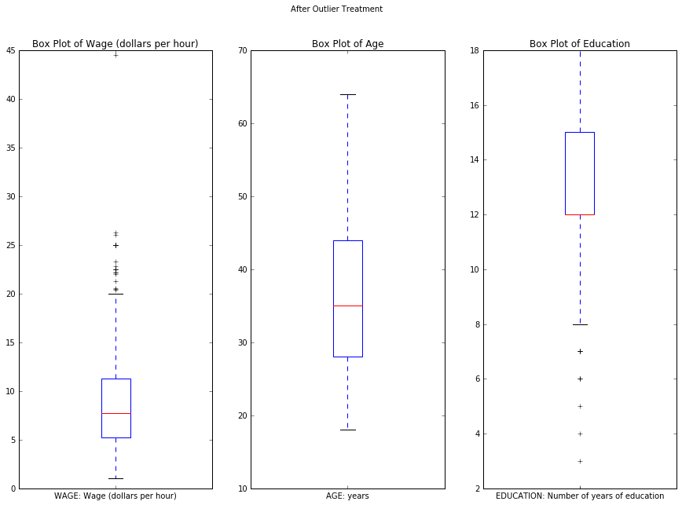

```python
#Again plotting Box plots to see how the outliers are now spread out
fig, axes = plt.subplots(nrows=1, ncols=3,figsize=(15,10))
ip['WAGE: Wage (dollars per hour)'].plot(kind='box',ax=axes[0],showfliers=True)
axes[0].set_title("Box Plot of Wage (dollars per hour)")

ip['AGE: years'].plot(kind='box',ax=axes[1],showfliers=True)
axes[1].set_title("Box Plot of Age")

ip['EDUCATION: Number of years of education'].plot(kind='box',ax=axes[2],showfliers=True)
axes[2].set_title("Box Plot of Education")
plt.suptitle('After Outlier Treatment')
```

```python
ip.to_csv(r"Outlier_treated.csv",index=None)
```

Summary for Outlier Treatment:

1. Identification of outliers through Box plot, Histogram or Stem and Leaf Plot
2. Imputation of Ouliers (Generalized Imputation or Similar Case Imputation)